# Relation of Severe Weather Events on Public Health and Economy

## Data Processing

**Performed steps**:  
*Load the data from csv file*  
*Remove some unused variables to save memory*  
*Remove original data to save memory*  
*Calculate the damage*  
*Using levels(), it was found that the exponential has lots of values that were not explained in the documentation. These values were ignored. Only K, M, B were understood as 1000, 10^6 and 10^9, respectively.*  
*Property damage & crop damage were summed up to get the total damage*  
*Calculate total fatalities and injuries*

```r
# Load the data
storm_data_raw <- read.csv("~/Downloads/Data/repdata-data-StormData.csv")

# Remove unnecessary columns
good_columns <- c("EVTYPE",                  # Event type
                  "FATALITIES", "INJURIES",  # Fatalities & Injuries
                  "PROPDMG", "PROPDMGEXP",   # Property damange & its exponential
                  "CROPDMG", "CROPDMGEXP")   # Crop damage & its exponential
storm_data <- storm_data_raw[,good_columns]
summary(storm_data)
```

```
##                EVTYPE         FATALITIES          INJURIES
##  HAIL             :288661   Min.   :  0.0000   Min.   :   0.0000
##  TSTM WIND        :219940   1st Qu.:  0.0000   1st Qu.:   0.0000
##  THUNDERSTORM WIND: 82563   Median :  0.0000   Median :   0.0000
##  TORNADO          : 60652   Mean   :  0.0168   Mean   :   0.1557
##  FLASH FLOOD      : 54277   3rd Qu.:  0.0000   3rd Qu.:   0.0000
##  FLOOD            : 25326   Max.   :583.0000   Max.   :1700.0000
##  (Other)          :170878
##     PROPDMG          PROPDMGEXP        CROPDMG          CROPDMGEXP
##  Min.   :   0.00          :465934   Min.   :  0.000          :618413
##  1st Qu.:   0.00   K      :424665   1st Qu.:  0.000   K      :281832
##  Median :   0.00   M      : 11330   Median :  0.000   M      :  1994
##  Mean   :  12.06   0      :   216   Mean   :  1.527   k      :    21
##  3rd Qu.:   0.50   B      :    40   3rd Qu.:  0.000   0      :    19
##  Max.   :5000.00   5      :    28   Max.   :990.000   B      :     9
##                    (Other):    84                     (Other):     9
```

```r
# Remove original data to save space
remove(storm_data_raw)

# Calculate the total damage
levels(storm_data$PROPDMGEXP) <- c(
  "1", "1", "1", "1", "1", "1", "1", "1", "1", "1", "1", "1", "1",
  "1000000000", "1", "1", "1000", "1000000", "1000000")
levels(storm_data$CROPDMGEXP) <- c(
  "1", "1", "1", "1", "1000000000", "1000",
  "1000", "1000000", "1000000")
storm_data$PROPDMG <- storm_data$PROPDMG *
  as.integer(as.character(storm_data$PROPDMGEXP))
storm_data$CROPDMG <- storm_data$CROPDMG *
  as.integer(as.character(storm_data$CROPDMGEXP))
storm_data$DAMAGE <- storm_data$PROPDMG + storm_data$CROPDMG

# Calculate total injuries & fatalities
storm_data$HEALTH <- storm_data$INJURIES + storm_data$FATALITIES
```

## Results

### Impact on Population health

Across the United States, which types of events (as indicated in the EVTYPE variable) are most harmful with respect to population health?

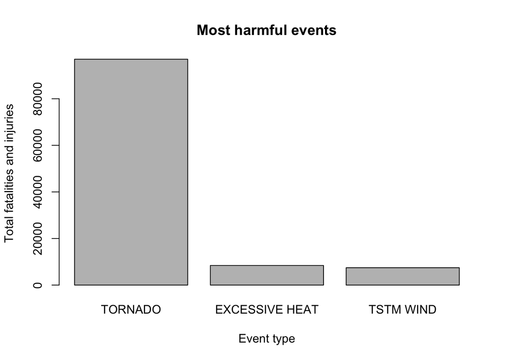

```r
total <- sort(
  tapply(storm_data$HEALTH, storm_data$EVTYPE, sum),
  decreasing = T)
barplot(head(total,3),
        main="Most harmful events",
        xlab="Event type",
        ylab="Total fatalities and injuries")
```

```r
max(total)
```

```
## [1] 96979
```

From the figure, it was found that Tornado has caused the most number of injuries and fatalities (96,980 fatalities and injuries), significantly more than any other type of events.

### Impact on Economy

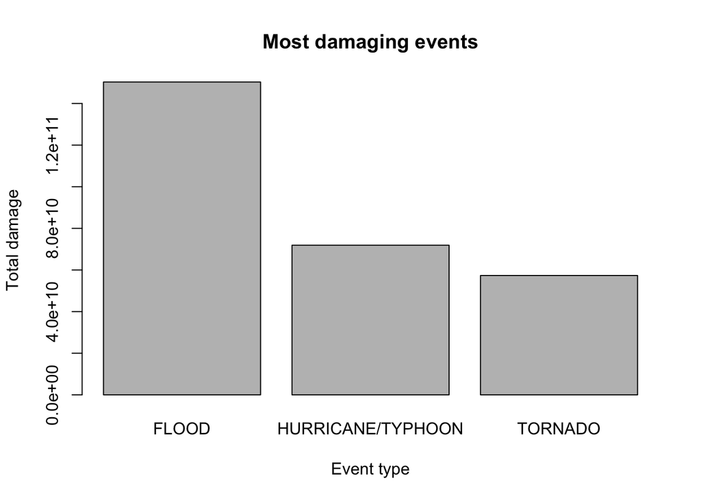

```r
total <- sort(
  tapply(storm_data$DAMAGE, storm_data$EVTYPE, sum),
  decreasing = T)
barplot(head(total,3),
        main="Most damaging events",
        xlab="Event type",
        ylab="Total damage")
```

```r
max(total)
```

```
## [1] 150319678257
```

From the figure, it was found that Flood has caused biggest damage (around 150 billions US dollars), much higher than any other events.